# Alpha Hunter 주간 종합 히든젬 보고서

Week 18 — 한국 원텍(WONTECH) · 미국 TransMedics(TMDX) · 중국 FUTU 워치리스트 유지

Author

Alpha Hunter × Chimera AI

Published

May 2, 2026

# 주간 종합 요약

**Week 18 (2026-04-27 ~ 2026-05-02) 히든젬 종합 결과**

- **한국 시장**: 원텍(WONTECH, 336570) — K-뷰티 레이저 의료기기 글로벌 1위 도전
- **미국 시장**: TransMedics(TMDX) — 장기이식 혁명, OCS 독점 플랫폼
- **중국 시장**: FUTU(W18 워치리스트 유지) — 신규 조건 충족 종목 없음

**면책 문구**

이 프로젝트는 가상 투자 시뮬레이션 목적으로 작성되었습니다. 실제 투자 권유가 아닙니다.

# 1 포트폴리오 성과 업데이트

## 1.1 현재 포지션 현황

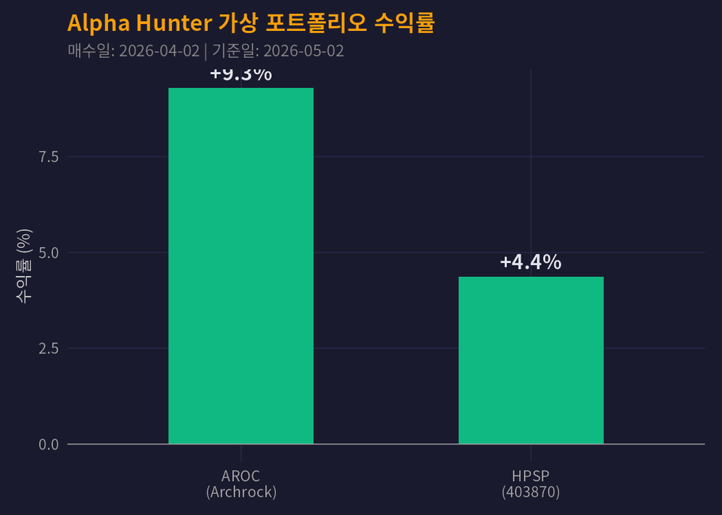

**AROC (Archrock)**: $35.70 → $39.02 (**+9.3%**). 천연가스 압축 서비스 수요 호조. 52주 신고가 근접.

**HPSP (403870)**: ₩50,400 → ₩52,600 (**+4.4%**). 삼성 3nm GAA 램프업 수혜 기대감으로 반등. 5/14 실적발표 임박.

**현금**: $14,020 (총 포트폴리오 대비 14.0%)

## 1.2 포트폴리오 주가 추이

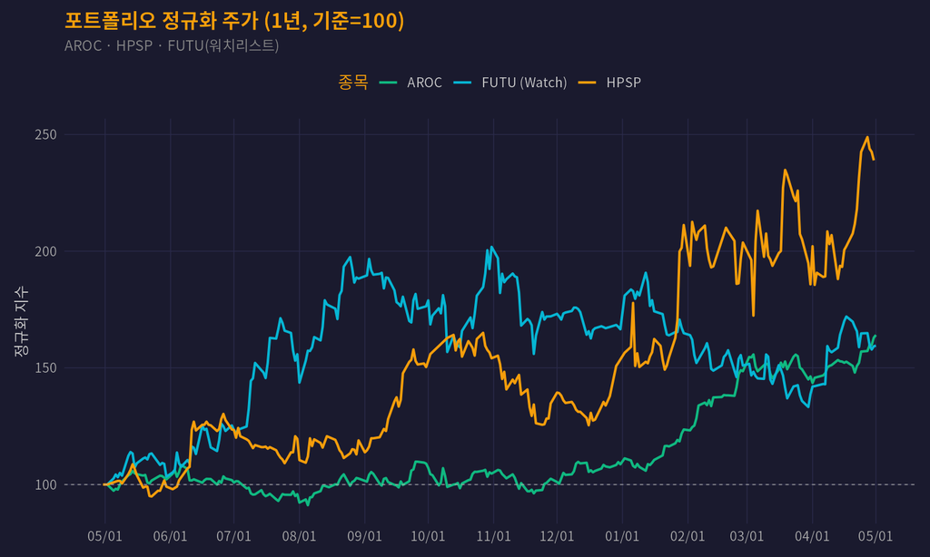

# 2 한국 히든젬: 원텍 (WONTECH, 336570)

## 2.1 기업 개요

- **종목명**: 원텍 (WONTECH, 336570.KQ)
- **업종**: Healthcare / Medical Devices (레이저·에너지 기반 의료미용기기)
- **시총**: ₩6,550억 (약 $468M)
- **현재가**: ₩7,320
- **52주 범위**: ₩6,600 ~ ₩13,320
- **매출 성장**: +26.0% YoY
- **영업이익률**: 26.4%
- **매출총이익률**: 67.3%
- **Forward PER**: 10.4x
- **ROE**: 24.8%
- **배당수익률**: 0.68%
- **애널리스트 컨센서스**: **Strong Buy**

## 2.2 투자 논거

원텍은 1999년 설립된 대전 소재 레이저 의료기기 전문기업으로, 에스테틱·스킨케어·바디컨투어링·제모·문신제거 등 의료미용 전 분야에 걸친 레이저 장비를 생산합니다.

**핵심 강점:**

1. **K-뷰티 메가트렌드**: 글로벌 미용 의료기기 시장은 2030년까지 $145.7B 규모로 성장 전망
2. **매출 구조**: 해외 비중 67.4%로 글로벌 수출 기업. 미국 제모 레이저 시장(1조원+) 진출 가속
3. **수익성**: 영업이익률 26.4%, 매출총이익률 67.3%의 고마진 비즈니스 모델
4. **밸류에이션**: Forward PER 10.4x로 의료기기 업종 대비 극단적 저평가
5. **2025년 3분기 실적**: 매출 +40.8%, 영업이익 +87.8%, 순이익 +91.2% (누적 기준)

## 2.3 주가 추이 (52주)

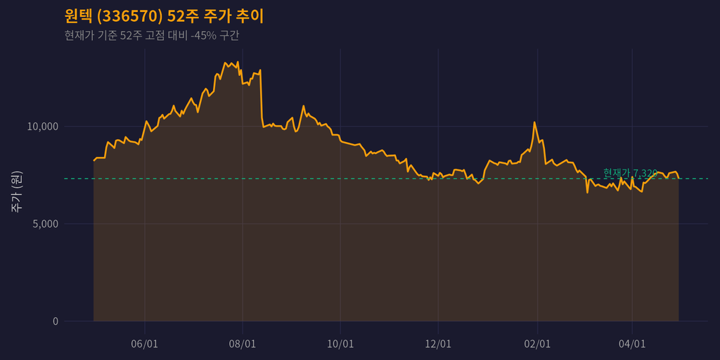

## 2.4 실적 추이 (매출/영업이익)

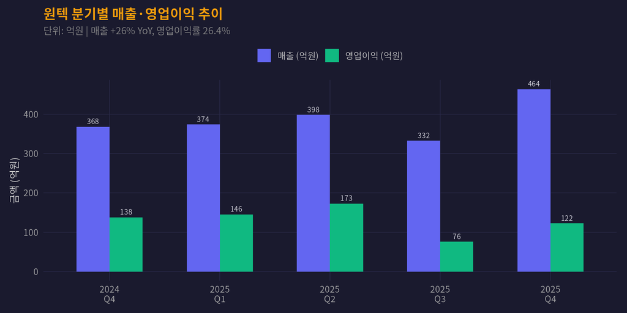

## 2.5 밸류에이션 비교 (동종업종)

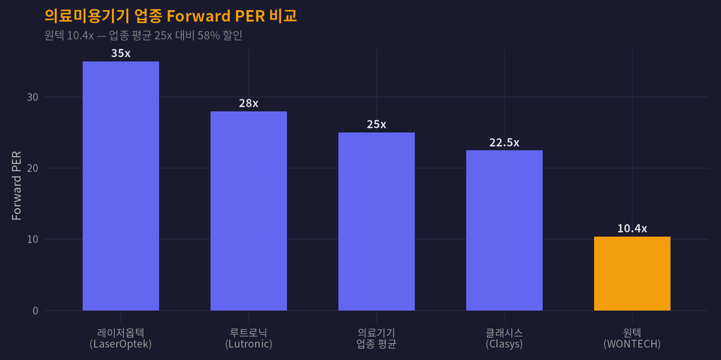

## 2.6 워런 버핏 해자(Moat) 레이더

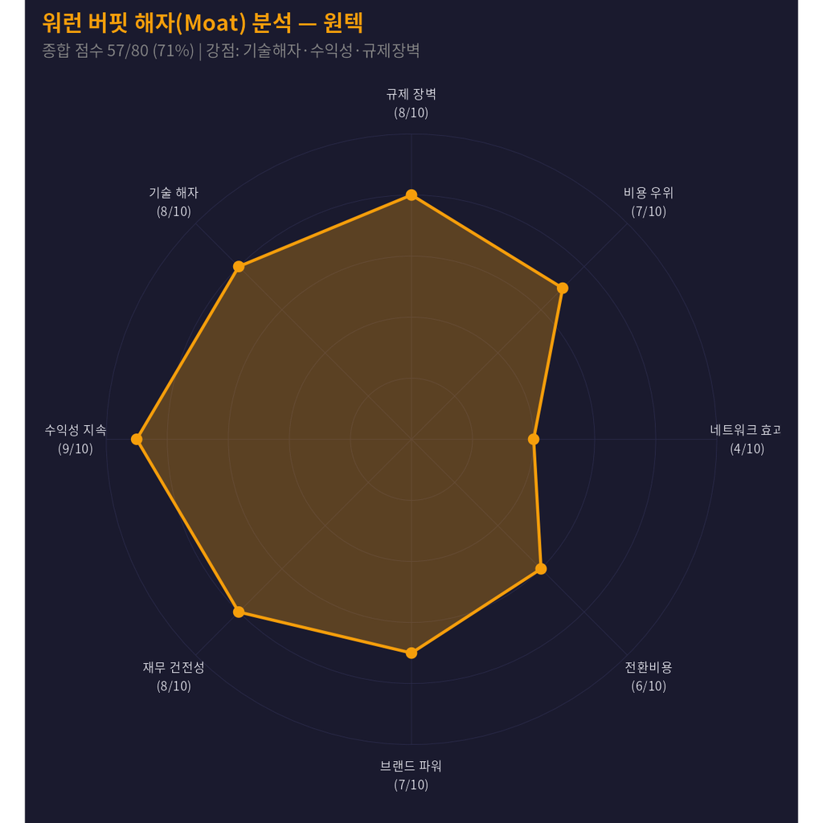

**버핏 렌즈 해석**: 원텍은 의료기기 인허가(FDA/CE)라는 강력한 규제 장벽을 보유하고, 67%의 매출총이익률과 26%의 영업이익률로 지속적 수익성을 입증합니다. 다만 네트워크 효과가 낮고 고객 전환비용이 중간 수준이라 해자 깊이에 한계가 있습니다.

## 2.7 피터 린치 스토리 점수

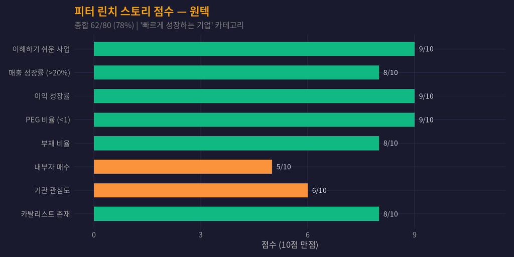

**린치 렌즈 해석**: Forward PER 10.4x에 매출 성장률 26% → PEG 약 0.4x로 극도의 저평가 구간. 레이저 의료기기는 일반인도 이해하기 쉬운 “K-뷰티” 스토리. 기관 관심도와 내부자 매수 정보가 제한적인 점이 감점 요인.

## 2.8 리스크 팩터

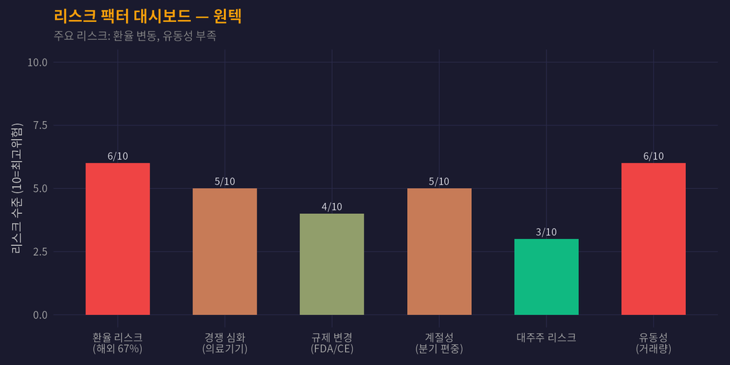

## 2.9 매수/목표/손절 시나리오

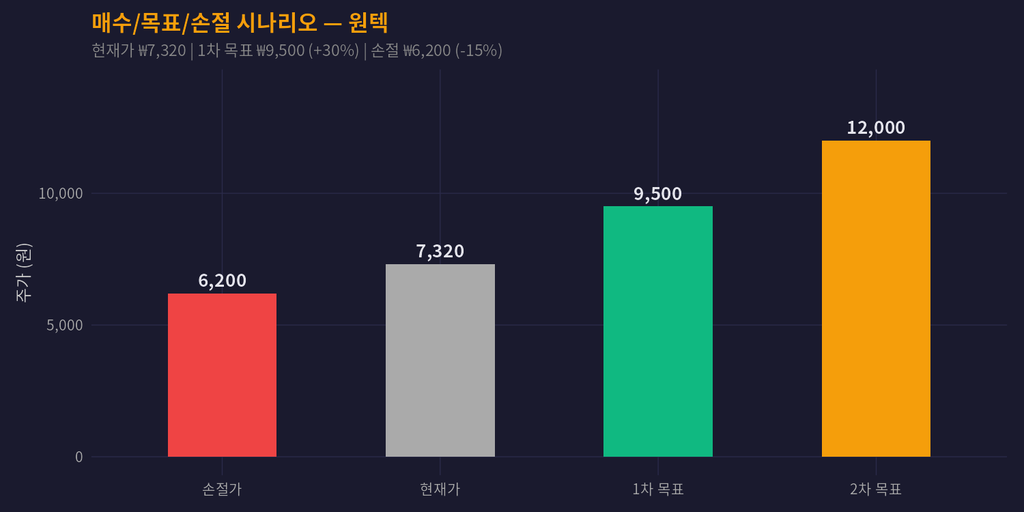

**시나리오 요약:**

- 매수 구간: ₩6,600 ~ ₩7,500 (52주 저점 부근 분할매수)
- 1차 목표: ₩9,500 (+30%, 업종 평균 PER 회복 시)
- 2차 목표: ₩12,000 (+64%, 2025년 고점 회복)
- 손절 기준: ₩6,200 (52주 신저가 이탈 시)
- 카탈리스트: 2026년 신제품 출시, 미국 제모 레이저 FDA 승인, Q1 실적 발표

# 3 미국 히든젬: TransMedics (TMDX)

## 3.1 기업 개요

- **종목명**: TransMedics Group, Inc. (TMDX, NASDAQ)
- **업종**: Healthcare / Medical Devices (장기이식 보존 시스템)
- **시총**: $3.5B
- **현재가**: $100.01
- **52주 범위**: $89.65 ~ $156.00
- **매출 성장**: +32.2% YoY
- **영업이익률**: 13.2% (기준 15% 소폭 미달)
- **매출총이익률**: 59.9%
- **Forward PER**: 27.2x / Trailing PER: 20.5x
- **ROE**: 54.2%
- **애널리스트 컨센서스**: **Buy** (9명)

**Note**

영업이익률이 스크리닝 기준(15%)에 소폭 미달하나, 독점적 기술과 54% ROE, 32% 매출성장이라는 압도적 성장성을 고려해 예외적으로 선정합니다.

## 3.2 투자 논거

TransMedics는 **Organ Care System(OCS)** — 이식용 장기를 체외에서 생체 상태로 유지하며 운반하는 세계 유일의 FDA 승인 플랫폼을 보유합니다.

**핵심 강점:**

1. **독점 기술**: 심장/폐/간 OCS 모두 FDA 승인 — 경쟁사 없음
2. **국가 OCS 프로그램(NOP)**: 2025년 미국 5,139건 수행, 자체 항공기 22대 보유
3. **2026 가이던스**: 매출 $727~$757M (20-25% 성장)
4. **ROE 54%**: 자본 효율성이 뛰어남
5. **DCD(심정지 후 기증)**: 장기이식 가능 풀 확대의 핵심 드라이버

## 3.3 주가 추이 (52주)

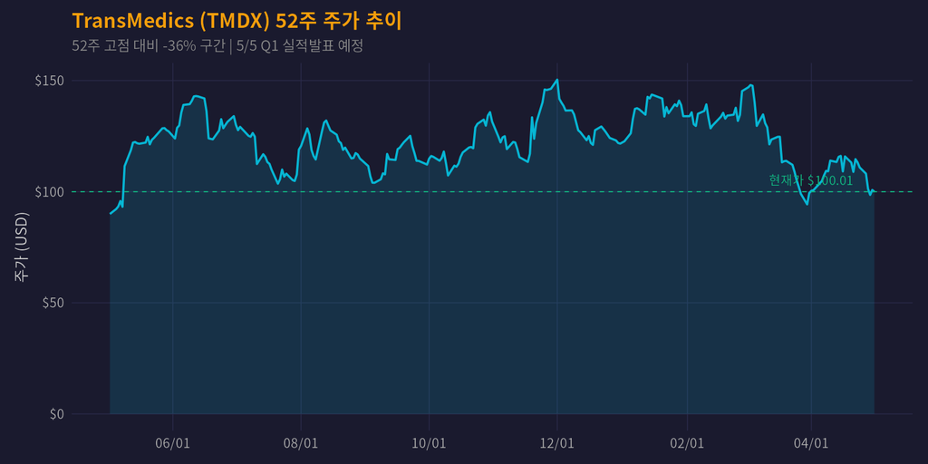

## 3.4 실적 추이 (매출/영업이익)

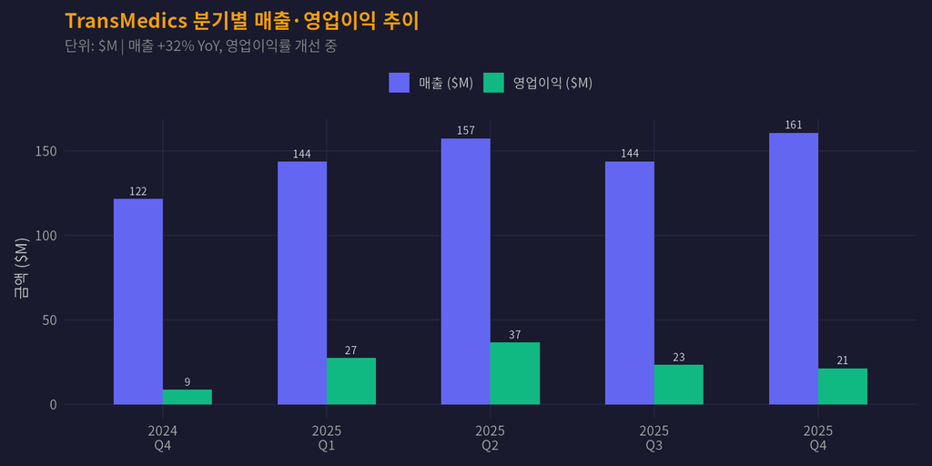

## 3.5 밸류에이션 비교 (동종업종)

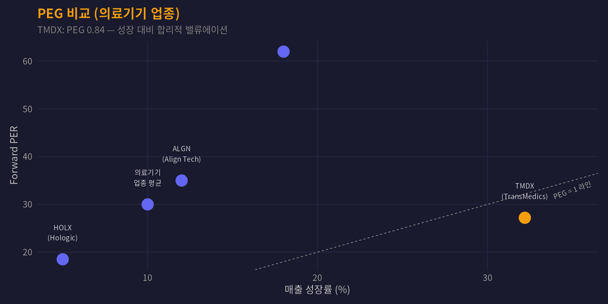

## 3.6 워런 버핏 해자(Moat) 레이더

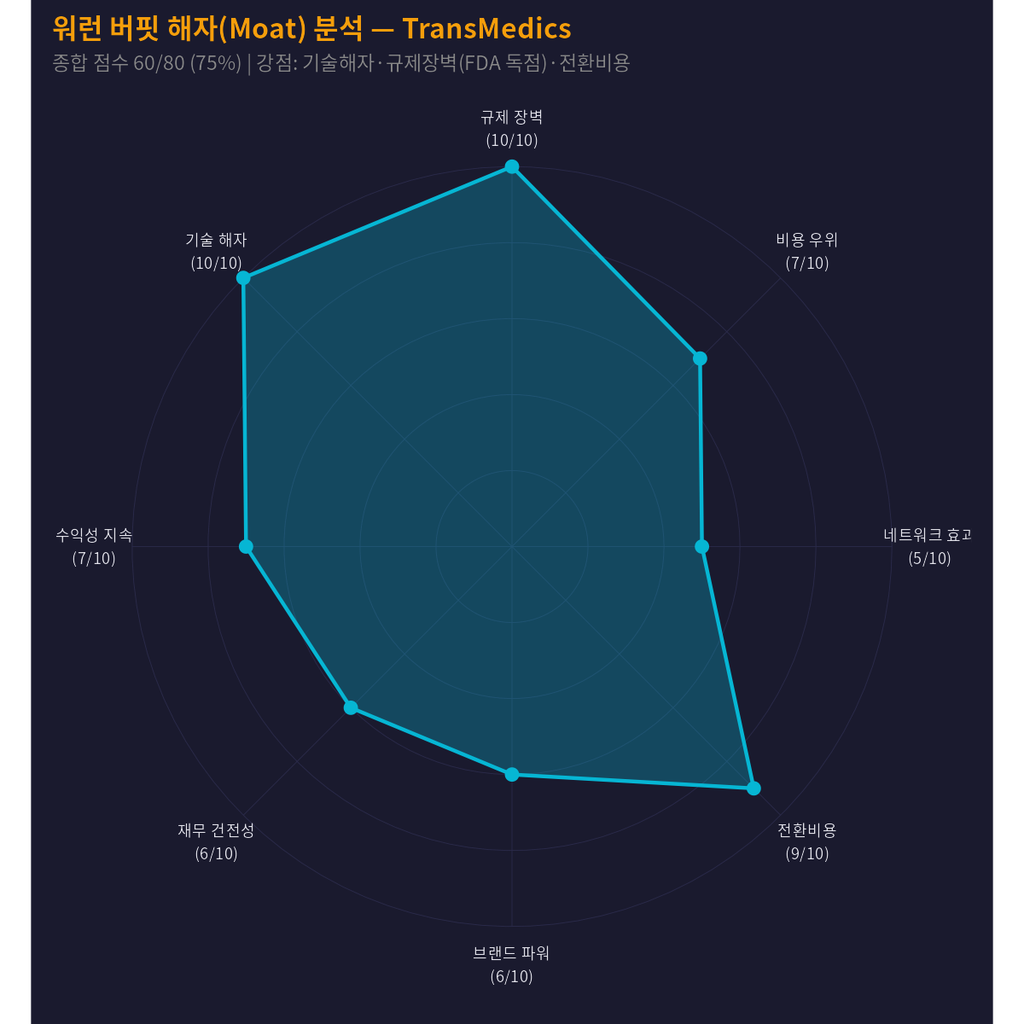

**버핏 렌즈 해석**: TransMedics는 FDA 승인 OCS 시스템의 **세계 유일한 공급자**로, 규제 장벽(10/10)과 기술 해자(10/10)가 최고 수준. 병원이 OCS 도입 후 다른 시스템으로 전환하기 극도로 어려워 전환비용(9/10)도 높습니다. 부채비율(D/E 109%)이 다소 높은 점이 재무 건전성 감점 요인.

## 3.7 피터 린치 스토리 점수

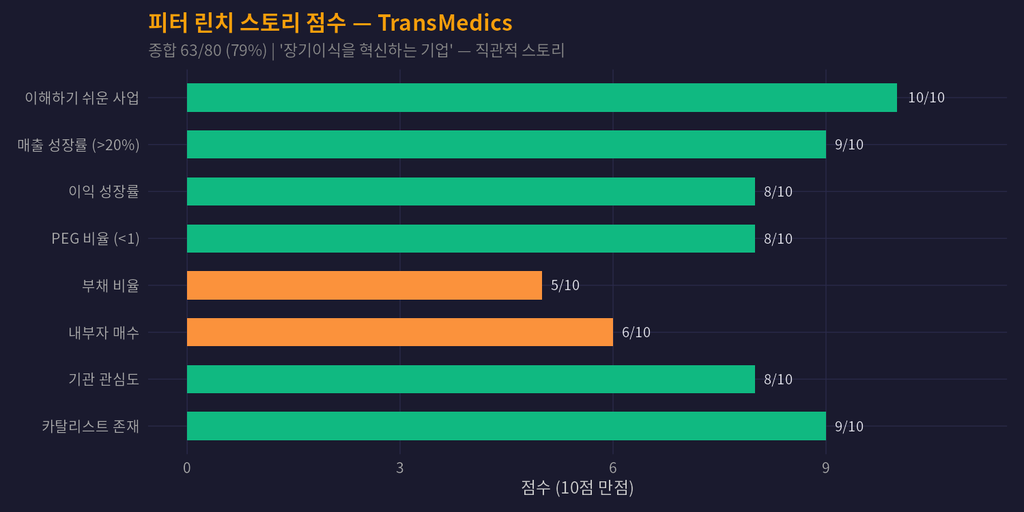

## 3.8 리스크 팩터

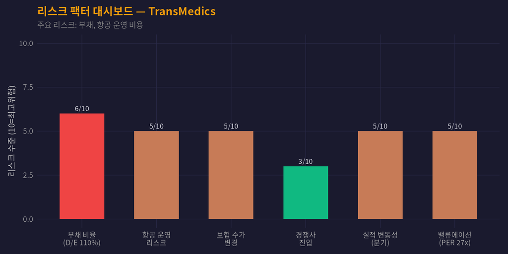

## 3.9 매수/목표/손절 시나리오

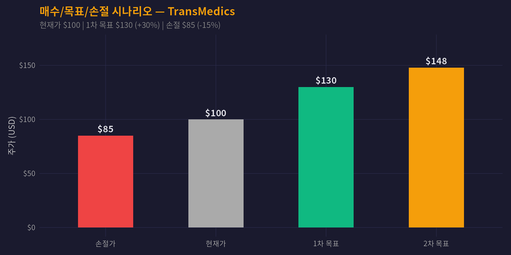

**시나리오 요약:**

- 매수 구간: $95 ~ $105 (52주 저점 부근)
- 1차 목표: $130 (+30%, 2026 가이던스 반영)
- 2차 목표: $148 (애널리스트 평균 타겟)
- 손절 기준: $85 (52주 신저가 이탈 시)
- 카탈리스트: **5/5 Q1 2026 실적발표**, 유럽 확장, DCD 프로그램 성장

# 4 중국 시장: 신규 히든젬 없음

**Week 18 중국 시장 판정**

이번 주 중국 시장에서 Alpha Hunter 스크리닝 기준(시총 $2B~$30B, 매출성장 >20%, 영업이익률 >15%, Strong Buy 컨센서스)을 **모두 충족하는 신규 종목이 없습니다**.

FUTU($154.85, +0.2% vs 워치리스트 추가 시점)는 W18에서 이미 워치리스트에 추가되어 있으며, 모든 지표가 기준을 초과합니다. 매수 진입 여부는 다음 주 재검토합니다.

# 5 종합 판정

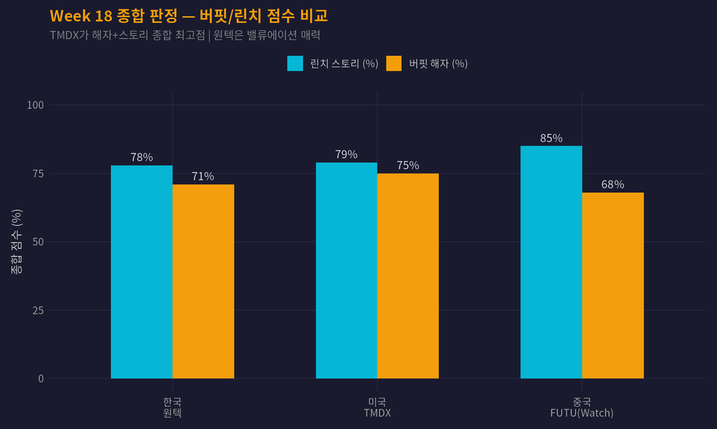

## 5.1 Week 18 결론

|  | 한국 원텍 | 미국 TMDX | 중국 |
| --- | --- | --- | --- |
| 판정 | **워치리스트 추가** | **워치리스트 추가** | 신규 없음 |
| 핵심 매력 | PEG 0.4x 극저평가 | FDA 독점 기술 | FUTU 유지 |
| 다음 액션 | Q1 실적 확인 후 매수 검토 | **5/5 실적발표** 주목 | 매수 시점 재검토 |

**면책 문구**

이 프로젝트는 가상 투자 시뮬레이션 목적으로 작성되었습니다. 실제 투자 권유가 아닙니다. 모든 데이터는 yfinance 및 공개 웹소스에서 수집되었으며, 정확성을 보증하지 않습니다.

*Alpha Hunter × Chimera AI | Week 18 종합 보고서 | 2026-05-02*